# PA1_template

Ryuta Hosaka

December 13, 2015

# Peer Assignment 1

Ryuta Hosaka

## Load and process data

Loading data from the file and convert date to date type.

```r
act <- read.csv("activity.csv", header = TRUE)
act$date <- as.Date(act$date, "%Y-%m-%d")
```

## What is the mean total of number of steps taken per day

Aggregate data by date and calculate mean and median of total steps by day.

```r
library(dplyr)
```

```r
library(ggplot2)
stepsByDate <- aggregate(act$steps ~ act$date, FUN = sum)
stepsByDate <- rename(stepsByDate, day = `act$date`, totalSteps = `act$steps`)
mean(stepsByDate$totalSteps)
```

```
## [1] 10766.19
```

```r
median(stepsByDate$totalSteps)
```

```
## [1] 10765
```

Plot steps by date by histogram.

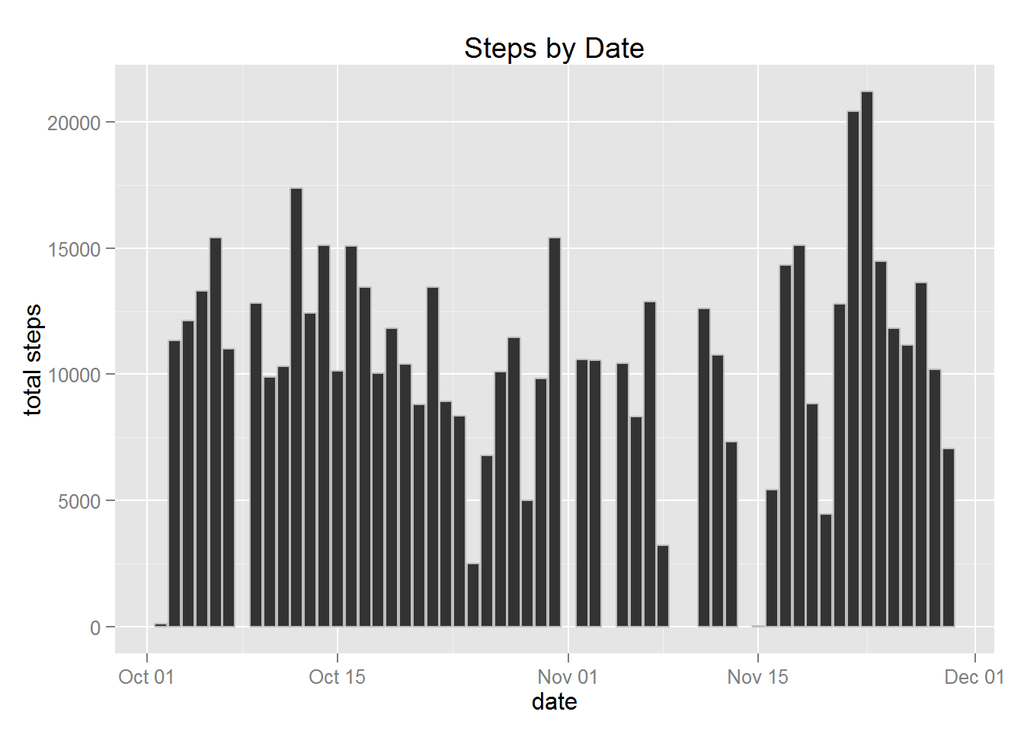

```r
ggplot(data=stepsByDate, aes(x=stepsByDate$day, y=stepsByDate$totalSteps))+geom_bar(colour="grey", stat="identity")+xlab("date")+ylab("total steps")+ggtitle("Steps by Date")
```

## What is the avarage daily activity pattern

Aggregate steps by each interval time and then calculate average

```r
avgStepsbyInt <- aggregate (act$steps ~ act$interval, FUN=mean)
avgStepsbyInt <- rename(avgStepsbyInt, interval = `act$interval`, avgSteps = `act$steps`)
```

Max average steps is found at interval 835. Below chart is showing time series plot of average steps.

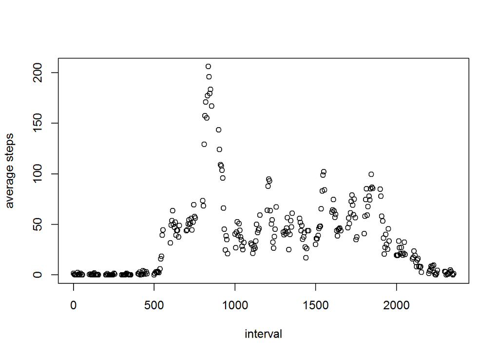

```r
plot(avgStepsbyInt$interval, avgStepsbyInt$avgSteps, xlab = "interval", ylab = "average steps")
```

## Impute missing values

Total number of missing values is 2304. Then next is to fill missing values. In this case I used average value by each step which I simply overwrite if original value is NA.

```r
act2 <- act
for (i in seq_along(act2$steps)){
  +     if(is.na(act2$steps[i])) act2$steps[i] <- avgStepsbyInt[avgStepsbyInt$interval == act2$interval[i], 2]
  else act2$steps[i] <- act2$steps[i]
}
stepsByDate2 <- aggregate(act2$steps ~ act2$date, FUN = sum)
stepsByDate2 <- rename(stepsByDate2, day = `act2$date`, totalSteps = `act2$steps`)
```

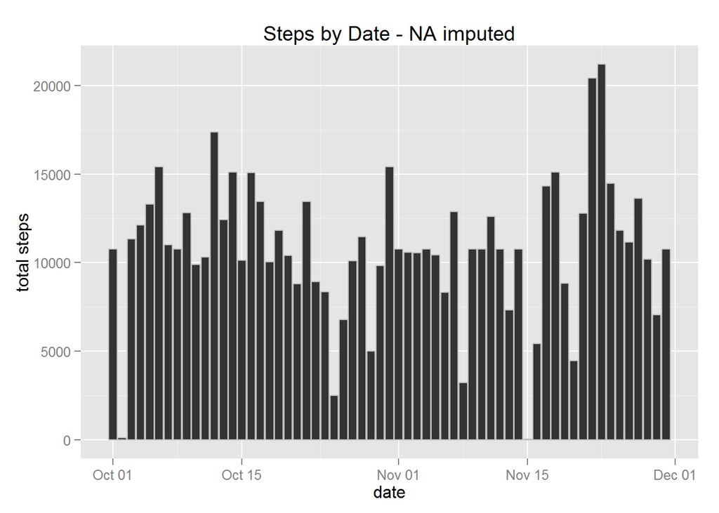

```r
ggplot(data=stepsByDate2, aes(x=stepsByDate2$day, y=stepsByDate2$totalSteps))+geom_bar(colour="grey", stat="identity")+xlab("date")+ylab("total steps")+ggtitle("Steps by Date - NA imputed")
```

## Difference in activity patter between weekday and weekend

I’ve created a function to flag weekday/weekend with weekday value derived from the date (with weekdays function). Here is the steps to create new data set to aggregate average value by date day type and interval.

```r
source('C:/Users/hryut/OneDrive/Documents/R Projects/Coursera-DS-5-WK2/flagweekday.R')
act$dayofweek <- lapply(act$date, FUN=weekdays)
act$weekdayflag <- lapply(act$dayofweek, FUN=flagweekday)
act$dayofweek <- as.character(act$dayofweek)
act$weekdayflag <-as.character(act$weekdayflag)
avgStepsByIntWdWe <-aggregate(act$steps ~ act$weekdayflag*act$interval, FUN=mean)
avgStepsByIntWdWe <- rename(avgStepsByIntWdWe, weekdayflag = `act$weekdayflag`, Interval = `act$interval`, avgSteps = `act$steps`)
```

And this is the plot to show the pattern of activity by day tyupe.

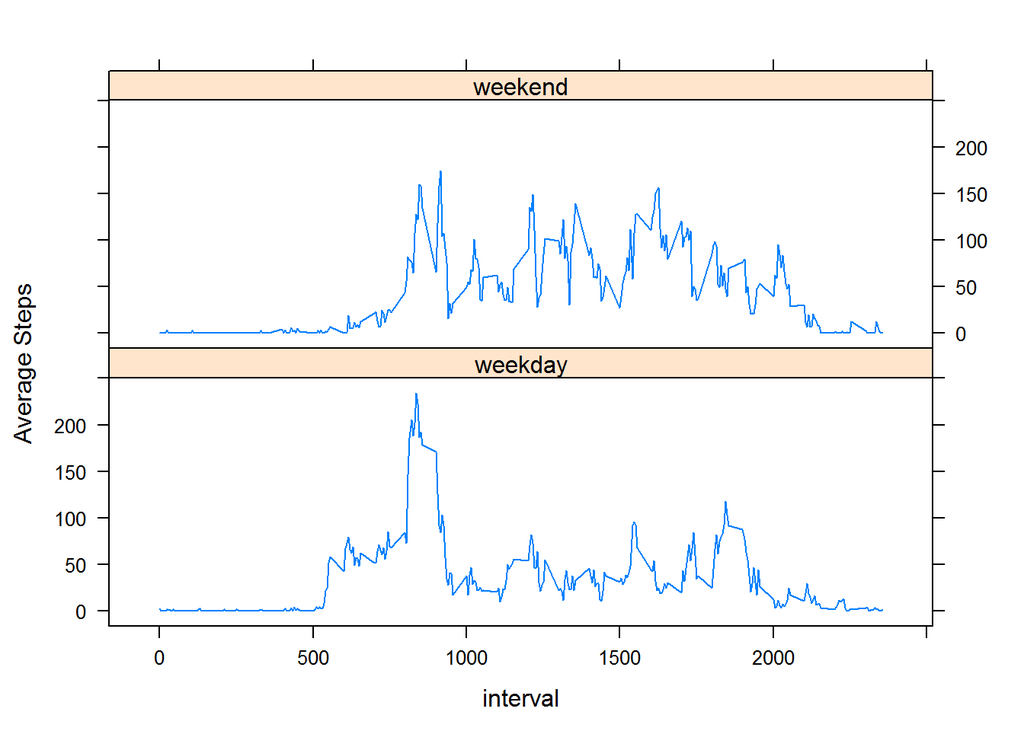

```r
library(lattice)
xyplot(avgSteps ~ Interval | weekdayflag, data = avgStepsByIntWdWe, type = "l", xlab = "interval", ylab = "Average Steps", layout = c(1,2))
```